# Regression Analysis on House, BIST and Employment Statistics

## Introduction

The main objective of this study is to analyze some of the most important economical statistics of Turkey with Linear Regression models to gain information about their relations to other economical or social metrics. The source code of the analysis can be found [here](https://github.com/BU-IE-360/spring24-OguzhanEngin/tree/main/files/HW_1).

The study consist of three analysis, each having different target variable. Potential economical and social features are analyzed and refined subsets of these features are used in the study to lessen the complexity.

The data, available in the Data folder, for this study is mostly gathered through Central Bank of the Republic of Turkey's EVDS API and Google Trends. The only feature which is not gathered from these sources is a binary variable to represent whether there are considerable amount of Covid-19 cases in Turkey or not. The source of this feature is Ministry of Health's daily reports.

## Initialization

```python
import os

import numpy as np
import pandas as pd
import statsmodels.api as sm

from matplotlib import pyplot as plt
import seaborn as sns

from evds import evdsAPI
pd.set_option('display.max_rows', 100)
```

```python
def get_best_lag(x, y, lags, x_label, y_label, title):
    '''Determine best lag (highest correlation) in a given range for a feature'''
    cross_corr_arr = [0]*lags
    for lag in range(lags):
        lag_corr = np.corrcoef(x.shift(lag).iloc[lag:], y.iloc[lag:])[0, 1]
        cross_corr_arr[lag] = lag_corr

    # Cross Correlation Plot
    plt.figure(figsize=(12, 9))
    plt.plot(cross_corr_arr)
    plt.xlabel(x_label)
    plt.ylabel(y_label)
    plt.title(title)
    plt.show()

    # Return highest correlated lag
    return np.argmax(np.abs(cross_corr_arr))
```

## Common Data

```python
# Need API key to update the data, otherwise read it from the Data folder
evds = evdsAPI(os.environ.get('EVDS_API_KEY'))
```

```python
# Get USD/TL data, for transforming TL to USD or to use as a external feature
usd_df = evds.get_data(['TP.DK.USD.A.EF.YTL'],
              startdate="01-01-2016",
              enddate="01-01-2024",
              aggregation_types='avg',
              formulas=[0],
              frequency=5
                )

usd_df = usd_df.rename({'Tarih': 'Date', 'TP_DK_USD_A_EF_YTL': 'USD/TL'}, axis=1)
usd_df.loc[:, 'Date'] = pd.to_datetime(usd_df['Date'])

usd_df.to_csv('./Data/EVDS/usd_tl.csv', index=False)
```

```python
# Read USD/TL data
usd_df = pd.read_csv('./Data/EVDS/usd_tl.csv')
usd_df.loc[:, 'Date'] = pd.to_datetime(usd_df['Date'])
```

```python
# Researched from the daily new case reports of Turkey, used as an external feature
covid_df = usd_df['Date'].to_frame().copy()
covid_df['Covid Period'] = np.where((covid_df['Date']>=pd.to_datetime('2020-03-01'))&(covid_df['Date']<=pd.to_datetime('2022-06-01')), 1, 0)
```

## House Sales

Housing is an important part of the Turkey economy in the recent years. Even though there are a lot of economical instability, it is expected for house sales to have less variance when compared to other financial statistics such as exchange rates or inflation. This is because even though house sales are related with economy (prices, interest rates etc.), they have more independent social factors that have impacts on the monthly average house sales.

Interested questions in this analysis:

- Does online house search have impact on house sales?
- Does online wedding hall search, which have the information of new marriages, have impact on house sales?
- Does online real estate search, which can have information about house investments, have impact on house sales?
- Does online foreign house search, which can include information about migrations' effect, have impact on house sales?
- Did Covid-19 have an effect on housing?
- Is there a trend or seasonality in the house sales?

### Data

```python
# First target variable to predict, average monthly number of houses sold across Turkey
home_sale_df = evds.get_data(['TP.AKONUTSAT1.TOPLAM'],
              startdate="01-01-2016",
              enddate="01-01-2024",
              aggregation_types='avg',
              formulas=[0],
              frequency=5
                )

home_sale_df = home_sale_df.rename({'Tarih': 'Date', 'TP_AKONUTSAT1_TOPLAM': 'Home Sales'}, axis=1)
home_sale_df.loc[:, 'Date'] = pd.to_datetime(home_sale_df['Date'])

home_sale_df.to_csv('./Data/EVDS/home_sales.csv', index=False)
```

```python
# Read house sales data
home_sale_df = pd.read_csv('./Data/EVDS/home_sales.csv')
home_sale_df.loc[:, 'Date'] = pd.to_datetime(home_sale_df['Date'])
```

```python
# Read 'sales home' google trend data
sales_home_search_df = pd.read_csv('./Data/Google Trends/ggltrd_saleshome.csv', skiprows=1)
sales_home_search_df = sales_home_search_df.rename({'Ay':'Date', 'satılık ev: (Türkiye)':'Sales Home SS'}, axis=1)
sales_home_search_df.loc[:, 'Date'] = pd.to_datetime(sales_home_search_df['Date'])
```

```python
# Read 'real estate' google trend data
realestate_search_df = pd.read_csv('./Data/Google Trends/ggl_trd_realestate.csv', skiprows=1)
realestate_search_df = realestate_search_df.rename({'Ay':'Date', 'gayrimenkul: (Türkiye)':'Real Estate SS'}, axis=1)
realestate_search_df.loc[:, 'Date'] = pd.to_datetime(realestate_search_df['Date'])
```

```python
# Read 'real estate agent' google trend data
rl_agent_search_df = pd.read_csv('./Data/Google Trends/ggltrd_agent.csv', skiprows=1)
rl_agent_search_df = rl_agent_search_df.rename({'Ay':'Date', 'emlakçı: (Türkiye)':'Agent SS'}, axis=1)
rl_agent_search_df.loc[:, 'Date'] = pd.to_datetime(rl_agent_search_df['Date'])
```

```python
# Read 'wedding hall' google trend data
wedhall_search_df = pd.read_csv('./Data/Google Trends/ggl_trd_wedhall.csv', skiprows=1)
wedhall_search_df = wedhall_search_df.rename({'Ay':'Date', 'düğün salonu: (Türkiye)':'Wedding Hall SS'}, axis=1)
wedhall_search_df.loc[:, 'Date'] = pd.to_datetime(wedhall_search_df['Date'])
```

```python
# Read 'foreign house' google trend data
pers_home_search_df = pd.read_csv('./Data/Google Trends/ggltrd_persian_home.csv', skiprows=1)
pers_home_search_df = pers_home_search_df.rename({'Ay':'Date', 'خانه: (Türkiye)':'Persian Home SS'}, axis=1)
pers_home_search_df.loc[:, 'Date'] = pd.to_datetime(pers_home_search_df['Date'])
```

```python
# Join the data for EDA
home_sales_analysis_df = home_sale_df.set_index('Date').join(sales_home_search_df.set_index('Date')).join(pers_home_search_df.set_index('Date'))\
    .join(realestate_search_df.set_index('Date')).join(rl_agent_search_df.set_index('Date')).join(wedhall_search_df.set_index('Date'))
```

### EDA

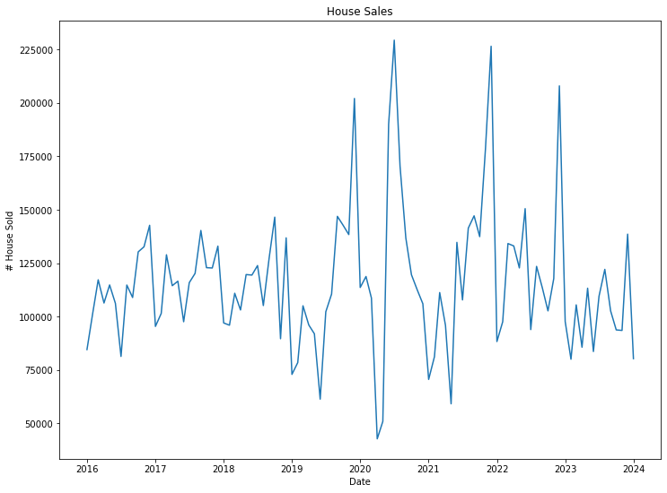

```python
# Target plot
plt.figure(figsize=(12, 9))
plt.plot(home_sale_df['Date'], home_sale_df['Home Sales'])
plt.title('House Sales')
plt.xlabel('Date')
plt.ylabel('# House Sold')
```

From this plot, we can see that there may be some seasonality and very little or no trend for average number of house sold in a month. Also there seems to be a regime change right before 2019 which increased the variance of the target, which will be explored in upcoming sections.

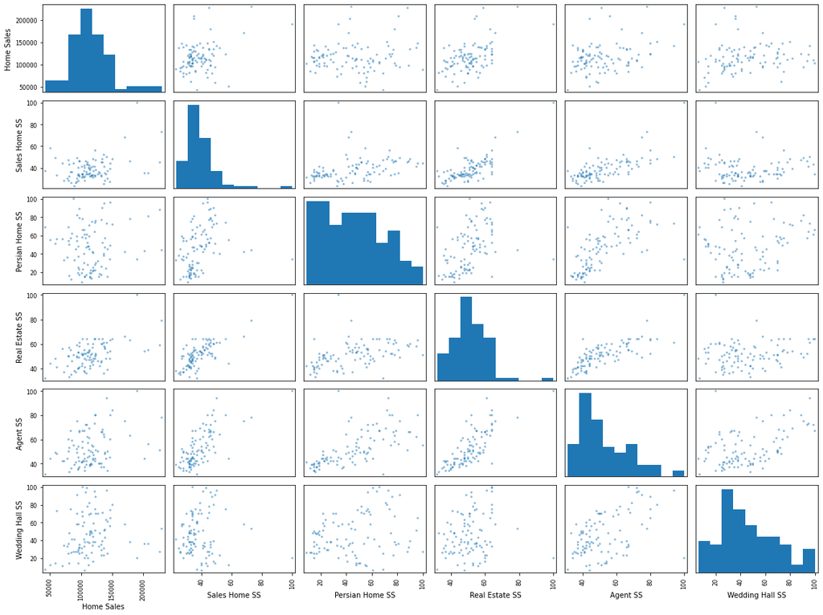

```python
# Scatter matrix plot
plt.figure(figsize=(16, 12))
pd.plotting.scatter_matrix(home_sales_analysis_df, figsize=(16, 12))
plt.tight_layout()
plt.show()
```

We can see that there is linear relations between the target and the features, there is no obvious non-linear patterns to transform the features. Some features seems to be correlated as well which may impact the coefficients and make them not interpretable, but no dimension reduction methods will be applied in this study because they are not included in the domain of the study.

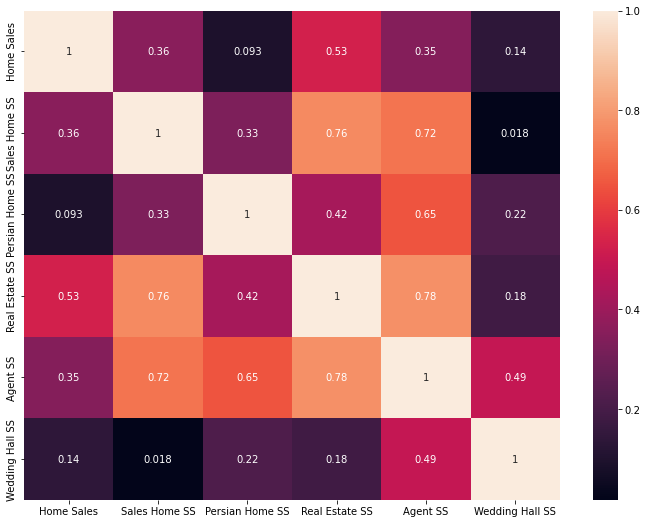

```python
# Correlation matrix
plt.figure(figsize=(12, 9))
sns.heatmap(home_sales_analysis_df.corr(), annot=True)
```

Google trend metrics about house search (especially Agent search) have high correlation, this probably will be reflected in their p-values.

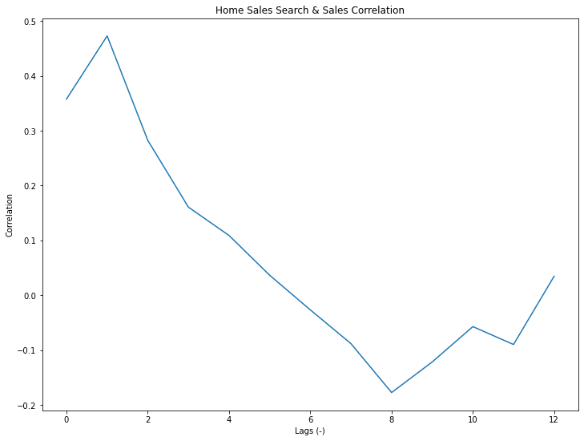

```python
# To plot the correlation function and to find the best lag (highest correlation) of the feature
best_lag_saleshome = get_best_lag(sales_home_search_df['Sales Home SS'], home_sale_df['Home Sales'], lags=13, x_label='Lags (-)', y_label='Correlation', title='Home Sales Search & Sales Correlation')
```

```python
best_lag_saleshome
```

```
1
```

It is reasonable that people search their future house for a month, therefore lag 1 of this feauture makes sense and will be used in the model.

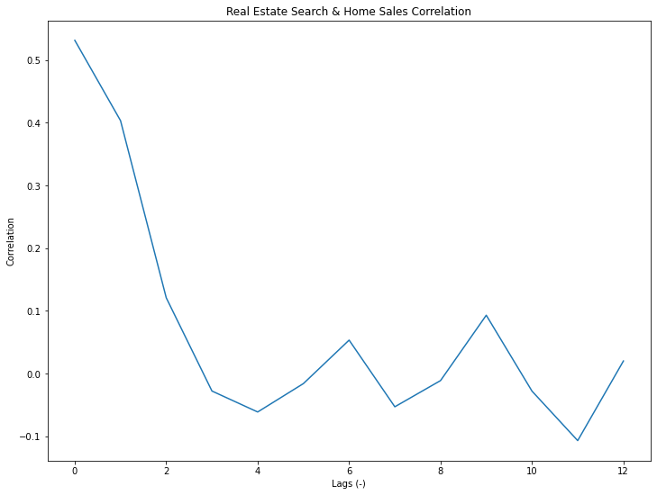

```python
best_lag_realestate = get_best_lag(realestate_search_df['Real Estate SS'], home_sale_df['Home Sales'], lags=13, x_label='Lags (-)', y_label='Correlation', title='Real Estate Search & Home Sales Correlation')
```

```python
best_lag_realestate
```

```
0
```

Real estate investments might be happening fast (within a month) in this volatile economical environment, therefore, since there is no concern of forecasting as well, lag 0 of this feature will be used.

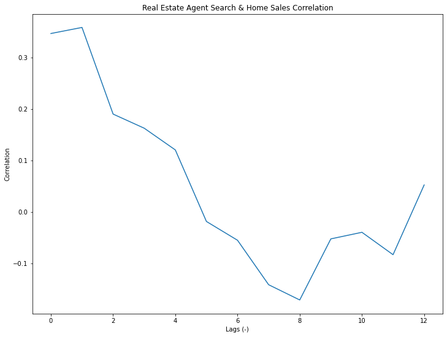

```python
best_lag_agent = get_best_lag(rl_agent_search_df['Agent SS'], home_sale_df['Home Sales'], lags=13, x_label='Lags (-)', y_label='Correlation', title='Real Estate Agent Search & Home Sales Correlation')
```

```python
best_lag_agent
```

```
1
```

When considering the time to research the real estate agent and them to find a suitable house, 1 month is reasonable. So, lag 1 will be used for this feature.

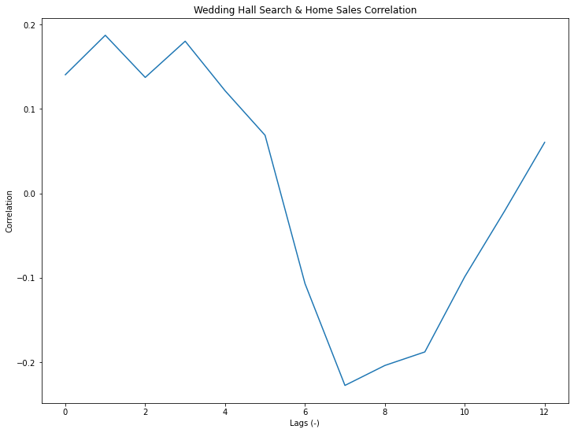

```python
best_lag_wedhall = get_best_lag(wedhall_search_df['Wedding Hall SS'], home_sale_df['Home Sales'], lags=13, x_label='Lags (-)', y_label='Correlation', title='Wedding Hall Search & Home Sales Correlation')
```

```python
best_lag_wedhall
```

```
7
```

Instead lag 1 version is used since absolute values are close and it is more interpretable. People who are newly wed might contribute to the sales of houses.

### Linear Regression Models

```python
# Base Home Sales X
home_sales_X = sm.add_constant(sales_home_search_df['Sales Home SS'].shift(1).iloc[2:])
home_sales_X['Pers Home SS'] = pers_home_search_df['Persian Home SS'].shift(2).iloc[2:]
home_sales_X['Agent SS'] = rl_agent_search_df['Agent SS'].shift(1).iloc[2:]
home_sales_X['Wedding Hall SS'] = wedhall_search_df['Wedding Hall SS'].shift(1).iloc[2:]
home_sales_X['Real Estate SS'] = realestate_search_df['Real Estate SS'].iloc[2:]
home_sales_X['trend'] = home_sales_X.reset_index(drop=True).index
home_sales_X['Is Covid'] = covid_df['Covid Period'].iloc[2:]
```

```python
hmsale_lr = sm.OLS(home_sale_df['Home Sales'].iloc[2:], home_sales_X)
hmsale_lr = hmsale_lr.fit()
hmsale_lr.summary()
```

OLS Regression Results

| Dep. Variable: | Home Sales | R-squared: | 0.487 |
| --- | --- | --- | --- |
| Model: | OLS | Adj. R-squared: | 0.445 |
| Method: | Least Squares | F-statistic: | 11.78 |
| Date: | Fri, 05 Apr 2024 | Prob (F-statistic): | 1.84e-10 |
| Time: | 15:26:12 | Log-Likelihood: | -1090.5 |
| No. Observations: | 95 | AIC: | 2197. |
| Df Residuals: | 87 | BIC: | 2217. |
| Df Model: | 7 |  |  |
| Covariance Type: | nonrobust |  |  |

|  | coef | std err | t | P>\|t\| | [0.025 | 0.975] |
| --- | --- | --- | --- | --- | --- | --- |
| const | -1493.7599 | 1.49e+04 | -0.100 | 0.920 | -3.11e+04 | 2.81e+04 |
| Sales Home SS | 633.1753 | 562.490 | 1.126 | 0.263 | -484.834 | 1751.185 |
| Pers Home SS | 673.8826 | 242.153 | 2.783 | 0.007 | 192.577 | 1155.189 |
| Agent SS | 190.5511 | 504.204 | 0.378 | 0.706 | -811.609 | 1192.711 |
| Wedding Hall SS | 292.9147 | 176.618 | 1.658 | 0.101 | -58.133 | 643.963 |
| Real Estate SS | 1685.7349 | 378.657 | 4.452 | 0.000 | 933.113 | 2438.357 |
| trend | -963.1879 | 216.282 | -4.453 | 0.000 | -1393.072 | -533.304 |
| Is Covid | -7600.5953 | 8160.435 | -0.931 | 0.354 | -2.38e+04 | 8619.154 |

| Omnibus: | 47.603 | Durbin-Watson: | 1.779 |
| --- | --- | --- | --- |
| Prob(Omnibus): | 0.000 | Jarque-Bera (JB): | 132.177 |
| Skew: | 1.802 | Prob(JB): | 1.99e-29 |
| Kurtosis: | 7.516 | Cond. No. | 723. |

Notes:  
[1] Standard Errors assume that the covariance matrix of the errors is correctly specified.

As we can see from the p-value of the Agent feature, it is not important for base linear regression model. This is probably due to the its correlation with other Google trend search metrics. Adjusted R^2 value is not up to the standarts, so the residual analysis is needed.

```python
hmsale_res_arr = hmsale_lr.resid
```

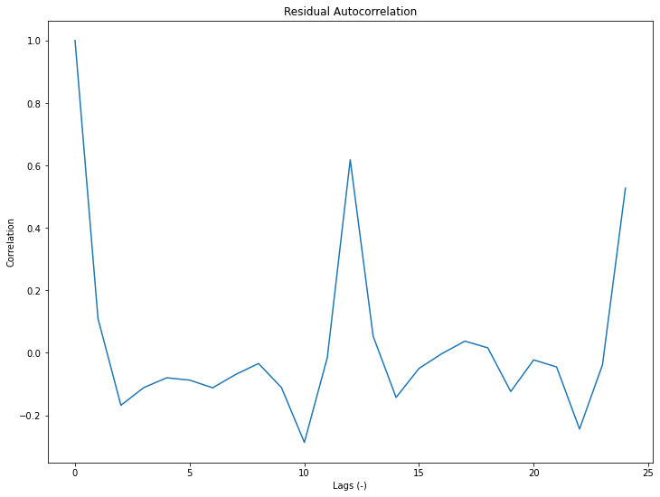

```
0
```

```python
get_best_lag(hmsale_res_arr, hmsale_res_arr, lags=25, x_label='Lags (-)', y_label='Correlation', title='Residual Autocorrelation')
```

Residual autocorrelation function indicates that there is strong seaosanality, therefore binary features will be added to the base feature set to model the seasonality.

```python
# Strong seasonality in base model residuals, so added seasonal binary features
home_sales_X = home_sales_X.join(pd.get_dummies(pd.to_datetime(sales_home_search_df.iloc[2:, 0]).dt.month, drop_first=True).astype(int))
```

```python
hmsale_lr = sm.OLS(home_sale_df['Home Sales'].iloc[2:], home_sales_X)
hmsale_lr = hmsale_lr.fit()
hmsale_lr.summary()
```

OLS Regression Results

| Dep. Variable: | Home Sales | R-squared: | 0.816 |
| --- | --- | --- | --- |
| Model: | OLS | Adj. R-squared: | 0.772 |
| Method: | Least Squares | F-statistic: | 18.68 |
| Date: | Fri, 05 Apr 2024 | Prob (F-statistic): | 6.63e-21 |
| Time: | 15:26:12 | Log-Likelihood: | -1041.9 |
| No. Observations: | 95 | AIC: | 2122. |
| Df Residuals: | 76 | BIC: | 2170. |
| Df Model: | 18 |  |  |
| Covariance Type: | nonrobust |  |  |

|  | coef | std err | t | P>\|t\| | [0.025 | 0.975] |
| --- | --- | --- | --- | --- | --- | --- |
| const | -2.381e+04 | 1.12e+04 | -2.117 | 0.037 | -4.62e+04 | -1413.475 |
| Sales Home SS | 1216.0311 | 400.339 | 3.038 | 0.003 | 418.687 | 2013.375 |
| Pers Home SS | 673.5203 | 160.539 | 4.195 | 0.000 | 353.778 | 993.262 |
| Agent SS | 53.3102 | 353.194 | 0.151 | 0.880 | -650.136 | 756.756 |
| Wedding Hall SS | 324.4764 | 164.629 | 1.971 | 0.052 | -3.410 | 652.363 |
| Real Estate SS | 1660.2109 | 255.527 | 6.497 | 0.000 | 1151.286 | 2169.136 |
| trend | -998.6923 | 143.072 | -6.980 | 0.000 | -1283.645 | -713.739 |
| Is Covid | -1.14e+04 | 5469.897 | -2.084 | 0.040 | -2.23e+04 | -507.131 |
| 2 | -1.28e+04 | 8223.981 | -1.557 | 0.124 | -2.92e+04 | 3576.453 |
| 3 | 5154.3112 | 8101.374 | 0.636 | 0.527 | -1.1e+04 | 2.13e+04 |
| 4 | 3762.9245 | 8149.473 | 0.462 | 0.646 | -1.25e+04 | 2e+04 |
| 5 | 6407.5167 | 8085.212 | 0.792 | 0.431 | -9695.578 | 2.25e+04 |
| 6 | 4342.8616 | 8376.317 | 0.518 | 0.606 | -1.23e+04 | 2.1e+04 |
| 7 | 3092.9663 | 9030.719 | 0.342 | 0.733 | -1.49e+04 | 2.11e+04 |
| 8 | 3345.6401 | 1.08e+04 | 0.311 | 0.757 | -1.81e+04 | 2.48e+04 |
| 9 | 645.5829 | 1.05e+04 | 0.061 | 0.951 | -2.03e+04 | 2.16e+04 |
| 10 | 9374.7486 | 9455.435 | 0.991 | 0.325 | -9457.382 | 2.82e+04 |
| 11 | 1.93e+04 | 8504.404 | 2.269 | 0.026 | 2358.776 | 3.62e+04 |
| 12 | 6.863e+04 | 7988.157 | 8.591 | 0.000 | 5.27e+04 | 8.45e+04 |

| Omnibus: | 1.926 | Durbin-Watson: | 1.618 |
| --- | --- | --- | --- |
| Prob(Omnibus): | 0.382 | Jarque-Bera (JB): | 1.366 |
| Skew: | 0.146 | Prob(JB): | 0.505 |
| Kurtosis: | 3.510 | Cond. No. | 1.69e+03 |

Notes:  
[1] Standard Errors assume that the covariance matrix of the errors is correctly specified.  
[2] The condition number is large, 1.69e+03. This might indicate that there are  
strong multicollinearity or other numerical problems.

Adjusted R^2 value increased significantly which indicates that there is infact significant seasonality. Also there is high number of correlated features which is indicated by high p values of some features. Dropping them manuanlly can reduce the complexity of the model which makes it more robust and also can make coefficients more interpretable (in the case of Google trend features).

```python
# p > .5 features eliminated manually after each feature adding iteration => To increase robustness & eliminate some of the correlated features
hmsale_lr = sm.OLS(home_sale_df['Home Sales'].iloc[2:], home_sales_X.drop(['Agent SS', 3, 4, 6, 7, 8, 9], axis=1))
hmsale_lr = hmsale_lr.fit()
hmsale_lr.summary()
```

OLS Regression Results

| Dep. Variable: | Home Sales | R-squared: | 0.814 |
| --- | --- | --- | --- |
| Model: | OLS | Adj. R-squared: | 0.789 |
| Method: | Least Squares | F-statistic: | 33.00 |
| Date: | Fri, 05 Apr 2024 | Prob (F-statistic): | 9.77e-26 |
| Time: | 15:26:12 | Log-Likelihood: | -1042.3 |
| No. Observations: | 95 | AIC: | 2109. |
| Df Residuals: | 83 | BIC: | 2139. |
| Df Model: | 11 |  |  |
| Covariance Type: | nonrobust |  |  |

|  | coef | std err | t | P>\|t\| | [0.025 | 0.975] |
| --- | --- | --- | --- | --- | --- | --- |
| const | -2.067e+04 | 9717.330 | -2.127 | 0.036 | -4e+04 | -1341.521 |
| Sales Home SS | 1253.9451 | 232.062 | 5.403 | 0.000 | 792.382 | 1715.508 |
| Pers Home SS | 680.3851 | 148.492 | 4.582 | 0.000 | 385.040 | 975.731 |
| Wedding Hall SS | 328.4151 | 85.847 | 3.826 | 0.000 | 157.668 | 499.162 |
| Real Estate SS | 1669.6940 | 231.213 | 7.221 | 0.000 | 1209.820 | 2129.568 |
| trend | -996.6879 | 124.476 | -8.007 | 0.000 | -1244.266 | -749.109 |
| Is Covid | -1.128e+04 | 5125.144 | -2.201 | 0.030 | -2.15e+04 | -1087.931 |
| 2 | -1.599e+04 | 6309.825 | -2.533 | 0.013 | -2.85e+04 | -3435.415 |
| 5 | 3322.6878 | 5876.115 | 0.565 | 0.573 | -8364.669 | 1.5e+04 |
| 10 | 6723.5614 | 5892.362 | 1.141 | 0.257 | -4996.109 | 1.84e+04 |
| 11 | 1.633e+04 | 5809.748 | 2.811 | 0.006 | 4774.022 | 2.79e+04 |
| 12 | 6.57e+04 | 5886.430 | 11.162 | 0.000 | 5.4e+04 | 7.74e+04 |

| Omnibus: | 1.602 | Durbin-Watson: | 1.616 |
| --- | --- | --- | --- |
| Prob(Omnibus): | 0.449 | Jarque-Bera (JB): | 1.044 |
| Skew: | 0.127 | Prob(JB): | 0.593 |
| Kurtosis: | 3.447 | Cond. No. | 717. |

Notes:  
[1] Standard Errors assume that the covariance matrix of the errors is correctly specified.

```python
# p > .5 features eliminated manually after each feature adding iteration => To increase robustness & eliminate some of the correlated features
hmsale_lr = sm.OLS(home_sale_df['Home Sales'].iloc[2:], home_sales_X.drop(['Agent SS', 3, 4, 5, 6, 7, 8, 9], axis=1))
hmsale_lr = hmsale_lr.fit()
hmsale_lr.summary()
```

OLS Regression Results

| Dep. Variable: | Home Sales | R-squared: | 0.813 |
| --- | --- | --- | --- |
| Model: | OLS | Adj. R-squared: | 0.791 |
| Method: | Least Squares | F-statistic: | 36.56 |
| Date: | Fri, 05 Apr 2024 | Prob (F-statistic): | 1.83e-26 |
| Time: | 15:26:12 | Log-Likelihood: | -1042.5 |
| No. Observations: | 95 | AIC: | 2107. |
| Df Residuals: | 84 | BIC: | 2135. |
| Df Model: | 10 |  |  |
| Covariance Type: | nonrobust |  |  |

|  | coef | std err | t | P>\|t\| | [0.025 | 0.975] |
| --- | --- | --- | --- | --- | --- | --- |
| const | -1.908e+04 | 9265.595 | -2.059 | 0.043 | -3.75e+04 | -656.507 |
| Sales Home SS | 1241.7828 | 230.126 | 5.396 | 0.000 | 784.152 | 1699.414 |
| Pers Home SS | 683.1405 | 147.810 | 4.622 | 0.000 | 389.203 | 977.078 |
| Wedding Hall SS | 323.4197 | 85.045 | 3.803 | 0.000 | 154.298 | 492.541 |
| Real Estate SS | 1656.0774 | 229.023 | 7.231 | 0.000 | 1200.640 | 2111.515 |
| trend | -995.5753 | 123.956 | -8.032 | 0.000 | -1242.075 | -749.076 |
| Is Covid | -1.105e+04 | 5088.586 | -2.172 | 0.033 | -2.12e+04 | -934.845 |
| 2 | -1.65e+04 | 6219.299 | -2.653 | 0.010 | -2.89e+04 | -4129.187 |
| 10 | 6414.7051 | 5843.186 | 1.098 | 0.275 | -5205.112 | 1.8e+04 |
| 11 | 1.588e+04 | 5731.945 | 2.771 | 0.007 | 4482.054 | 2.73e+04 |
| 12 | 6.515e+04 | 5780.558 | 11.270 | 0.000 | 5.37e+04 | 7.66e+04 |

| Omnibus: | 2.024 | Durbin-Watson: | 1.621 |
| --- | --- | --- | --- |
| Prob(Omnibus): | 0.363 | Jarque-Bera (JB): | 1.454 |
| Skew: | 0.163 | Prob(JB): | 0.483 |
| Kurtosis: | 3.510 | Cond. No. | 665. |

Notes:  
[1] Standard Errors assume that the covariance matrix of the errors is correctly specified.

Residual analysis is needed to be more confident about the current model and whether the assumptions hold about Linear Regression.

```python
home_sales_X = home_sales_X.drop(['Agent SS', 3, 4, 5, 6, 7, 8, 9], axis=1)
```

```python
hmsale_res_arr = hmsale_lr.resid
```

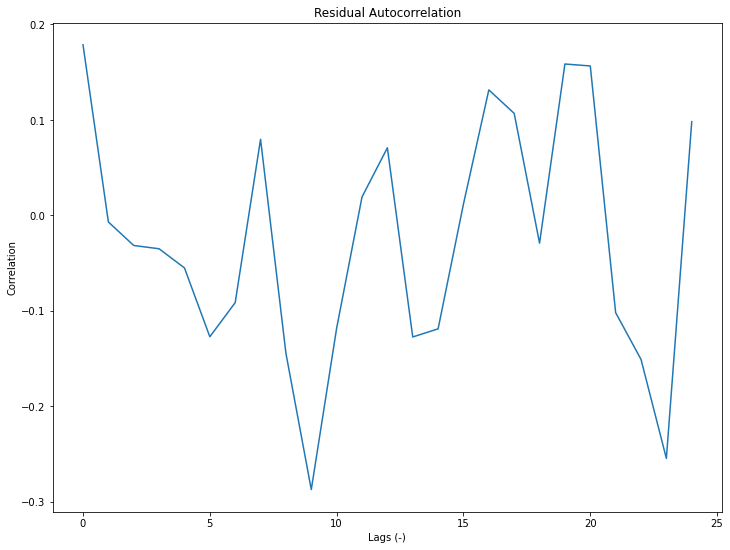

```
9
```

```python
# Autocorrelation starting from lag 1
get_best_lag(hmsale_res_arr.shift(1).iloc[1:], hmsale_res_arr.iloc[1:], lags=25, x_label='Lags (-)', y_label='Correlation', title='Residual Autocorrelation')
```

Residual autocorrelation function seems promising, it is within a small band and there is no obvious pattern. Further residual analysis is needed to check modelling assumptions.

### Residual Analysis

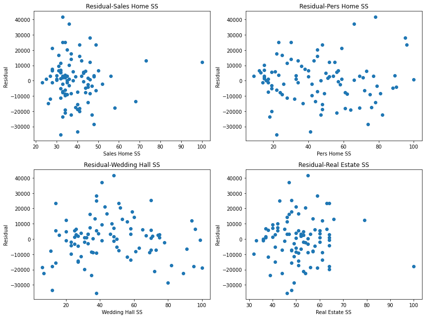

```python
# Residual - Features
fig, ax_arr = plt.subplots(nrows=2, ncols=2, figsize=(12, 9))

a = 1
for i in range(2):
    for j in range(2):
        ax = ax_arr[i, j]
        comp_feature = home_sales_X.columns[a]
        ax.scatter(home_sales_X[comp_feature], hmsale_res_arr)
        ax.set_title('Residual-' + comp_feature)
        ax.set_xlabel(comp_feature)
        ax.set_ylabel('Residual')
        a+=1

plt.tight_layout()
plt.show()
```

There is no obvious pattern between the residuals and the features which is good, otherwise there would be more information to expoit and our model would be inefficient.

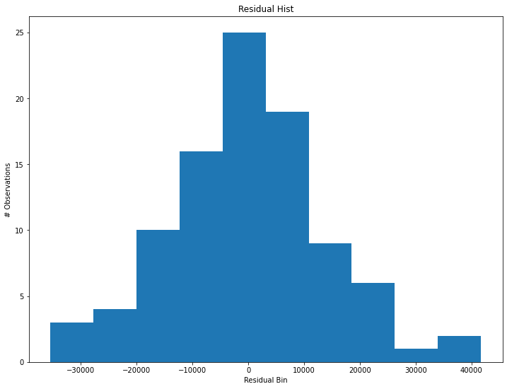

```python
# Residual histogram
plt.figure(figsize=(12, 9))
plt.title('Residual Hist')
plt.hist(hmsale_res_arr)
plt.xlabel('Residual Bin')
plt.ylabel('# Observations')
```

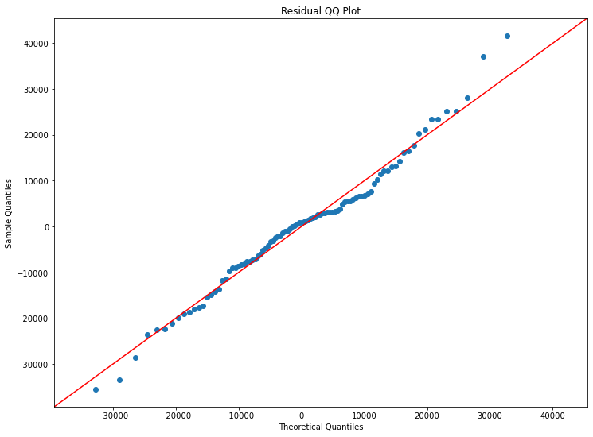

```python
# QQ plot for normality assumption
plt.figure(figsize=(12, 9))
ax = plt.subplot()
sm.qqplot(hmsale_res_arr, loc=0, scale=hmsale_res_arr.std(), ax=ax, line='45')
plt.title('Residual QQ Plot')
plt.show()
```

Residuals seem to be distributed normally around 0 (altough there are points that the model can't explain), which is an assumption we need to satisfy.

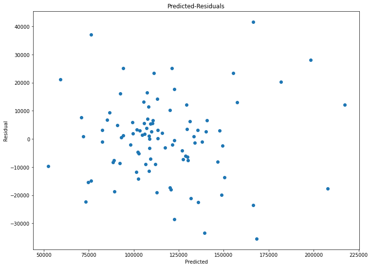

```python
plt.figure(figsize=(12, 9))
plt.scatter(hmsale_lr.predict(home_sales_X), hmsale_res_arr)
plt.title('Predicted-Residuals')
plt.xlabel('Predicted')
plt.ylabel('Residual')
```

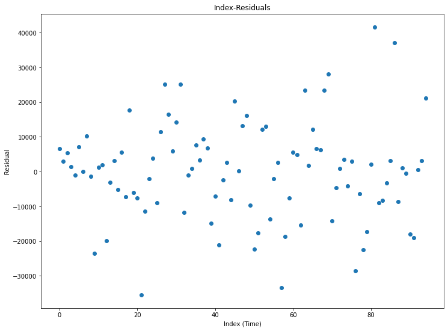

```python
plt.figure(figsize=(12, 9))
plt.scatter(range(len(hmsale_res_arr)), hmsale_res_arr)
plt.title('Index-Residuals')
plt.xlabel('Index (Time)')
plt.ylabel('Residual')
```

We need to observe more data points to see whether the variance of the residualds change overtime (which is very normal in current economical conditions) or the points in last parts are outliers. Apart from those points, variance of the residuals seems to be constant (which is an another assumption we need to satisfy).

```python
sm.stats.acorr_ljungbox(hmsale_res_arr, lags=[12], return_df=True)
```

|  | lb_stat | lb_pvalue |
| --- | --- | --- |
| 12 | 17.132416 | 0.144684 |

```python
sm.stats.acorr_ljungbox(hmsale_res_arr, lags=[24], return_df=True)
```

|  | lb_stat | lb_pvalue |
| --- | --- | --- |
| 24 | 33.12257 | 0.101514 |

Since p value > .05, we fail to reject the null hypothesis that residuals are not autocorrelated up to and including lag 12. Therefore, assumption of independent errors holds for this model, even though it is not with very high confidence level. Therefore all assumptions of the linear regression holds for this model with not very high confidence levels.

## BIST Volume

BIST is Turkey's main stock exchange platform which makes it very important for the Turkish economy. The volume of the trades in BIST can indicate the interest to the stock market and investments. It is expected for BIST volume to be very volitile in current conditions and therefore hard to model with a linear model (or maybe with any model depending on data quality). BIST volume will be analyzed in terms of USD.

Interested questions in this analysis:

- Does interest rates have an effect on BIST volume?
- Does online stock market search, impact BIST volume?
- Does online gold search, which indicates the interest in investments, have an impact on BIST volume?
- Does USD exchange rate have impact on BIST volume even though volume is in terms of dollars?
- Is there a trend or seasonality in the BIST volume?

### Data

```python
# Get BIST volume data
bist_vol_df = evds.get_data(['TP.MK.ISL.HC'],
              startdate="01-01-2016",
              enddate="01-01-2024",
              aggregation_types='avg',
              formulas=[0],
              frequency=5
                )
bist_vol_df = bist_vol_df.rename({'Tarih': 'Date', 'TP_MK_ISL_HC': 'BIST Volume'}, axis=1)
bist_vol_df.loc[:, 'Date'] = pd.to_datetime(bist_vol_df['Date'])
# Convert to USD
bist_vol_df['BIST Volume'] = bist_vol_df['BIST Volume']/usd_df['USD/TL']
```

```python
np.corrcoef(home_sale_df['Home Sales'], bist_vol_df['BIST Volume'])[0, 1]
```

```
0.07225115936367427
```

```python
# Get interest rate data to use as an external feature
interest_rate_df = evds.get_data(['TP.KTF17'],
              startdate="01-01-2016",
              enddate="01-01-2024",
              aggregation_types='avg',
              formulas=[0],
              frequency=5
                )
interest_rate_df = interest_rate_df.rename({'Tarih': 'Date', 'TP_KTF17': 'Interest Rate'}, axis=1)
interest_rate_df.loc[:, 'Date'] = pd.to_datetime(interest_rate_df['Date'])

interest_rate_df.to_csv('./Data/EVDS/interest_rate.csv', index=False)
```

```python
# Read interest rate search data
interest_rate_df = pd.read_csv('./Data/EVDS/interest_rate.csv')
interest_rate_df.loc[:, 'Date'] = pd.to_datetime(interest_rate_df['Date'])
```

```python
# Read stock market search data
stcmrkt_search_df = pd.read_csv('./Data/Google Trends/ggltrd_stockmarket.csv', skiprows=1)
stcmrkt_search_df = stcmrkt_search_df.rename({'Ay':'Date', 'Borsa: (Türkiye)':'Stock Market SS'}, axis=1)
stcmrkt_search_df.loc[:, 'Date'] = pd.to_datetime(stcmrkt_search_df['Date'])
```

```python
# Read gold search data
gold_search_df = pd.read_csv('./Data/Google Trends/ggltrd_gold.csv', skiprows=1)
gold_search_df = gold_search_df.rename({'Ay':'Date', 'Altın: (Türkiye)':'Gold SS'}, axis=1)
gold_search_df.loc[:, 'Date'] = pd.to_datetime(gold_search_df['Date'])
```

```python
# Join the data for EDA
bist_vol_analysis_df = bist_vol_df.set_index('Date').join(stcmrkt_search_df.set_index('Date')).join(gold_search_df.set_index('Date'))\
                        .join(usd_df.set_index('Date')).join(interest_rate_df.set_index('Date'))
```

### EDA

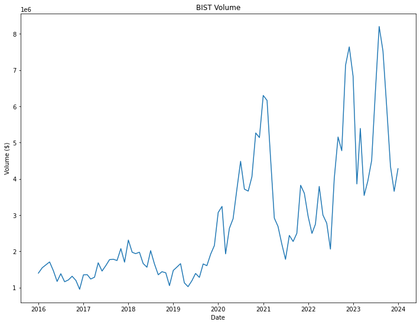

```python
plt.figure(figsize=(12, 9))
plt.plot(bist_vol_df['Date'], bist_vol_df['BIST Volume'])
plt.title('BIST Volume')
plt.xlabel('Date')
plt.ylabel('Volume ($)')
```

There seems to be a trend and also seasonality. After 2019, the target value have higher values and volatility.

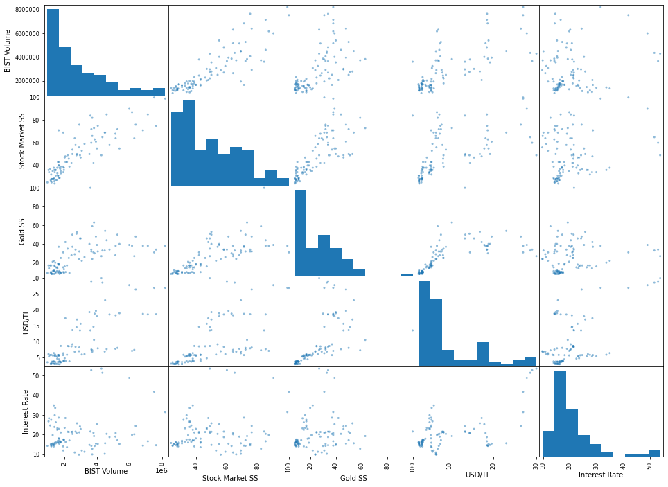

```python
pd.plotting.scatter_matrix(bist_vol_analysis_df, figsize=(16, 12))
plt.show()
```

There are linear relations between the target and the features(other than interest rate) are correlated amongst themselves as well. There is no need for feature transformation in this analysis as well.

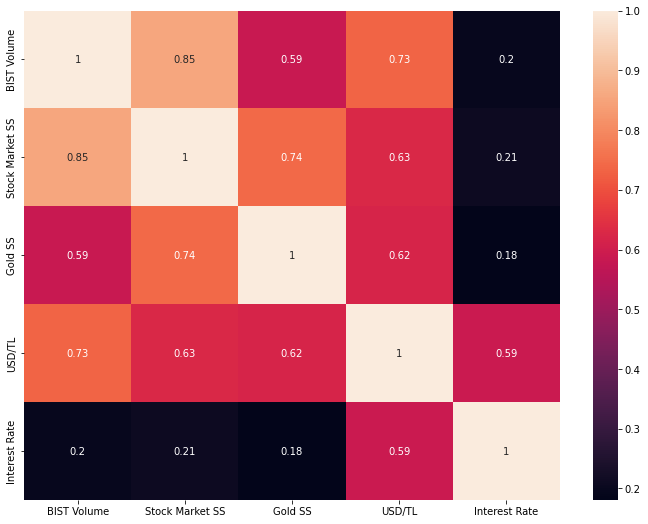

```python
# Correlation matrix
plt.figure(figsize=(12, 9))
sns.heatmap(bist_vol_analysis_df.corr(), annot=True)
```

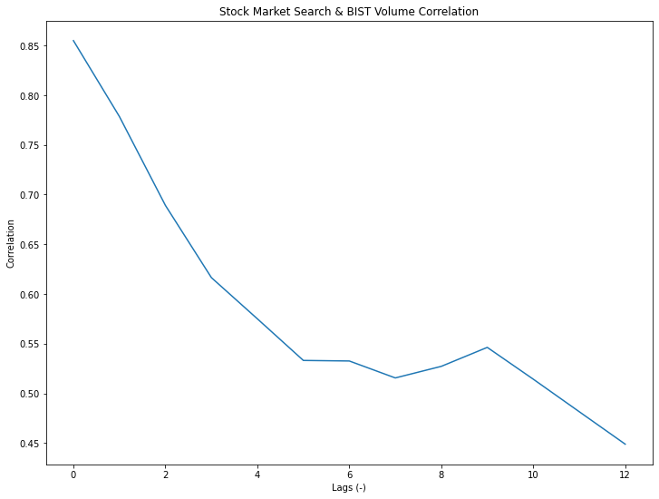

```python
best_lag_stcmrkt = get_best_lag(stcmrkt_search_df['Stock Market SS'], bist_vol_df['BIST Volume'], lags=13, x_label='Lags (-)', y_label='Correlation', title='Stock Market Search & BIST Volume Correlation')
```

```python
best_lag_stcmrkt
```

```
0
```

Very high correlation, it seems like Google search explains the volume very well. Online transactions might explain the very large percent of the volume of the stock markets, therefore this makes sense.

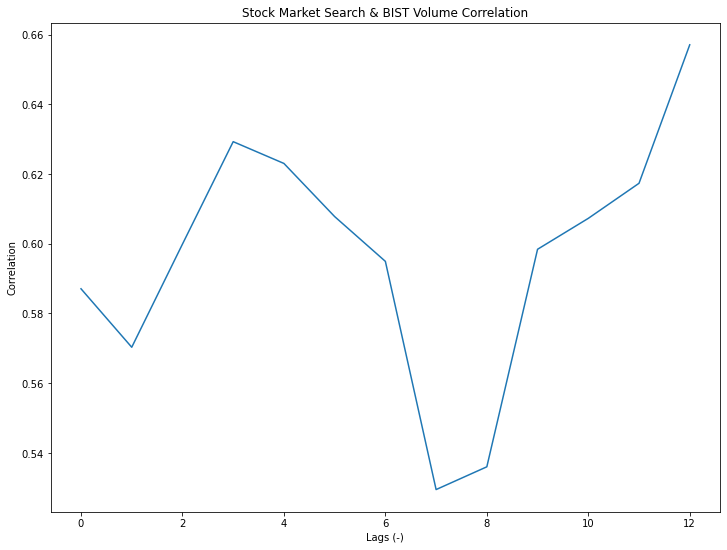

```python
best_lag_gold = get_best_lag(gold_search_df['Gold SS'], bist_vol_df['BIST Volume'], lags=13, x_label='Lags (-)', y_label='Correlation', title='Stock Market Search & BIST Volume Correlation')
```

```python
best_lag_gold
```

```
12
```

Lag 3 is used because it is more interpretable & its value is close to lag 12 correlation. The interest in the investments might take time to turn into interest in stock market investments, therefore 3 months makes sense.

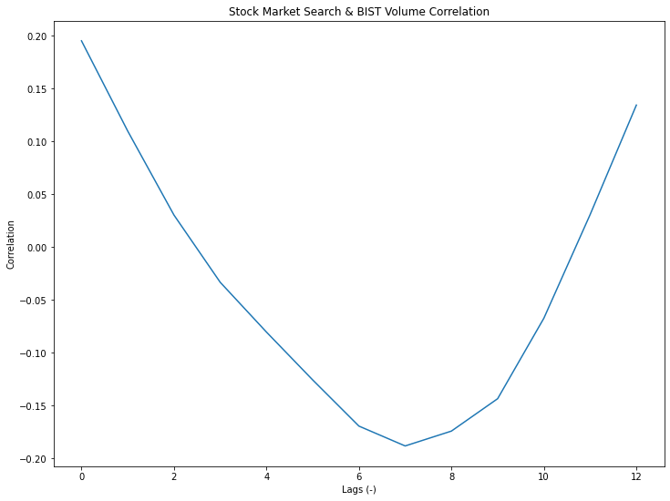

```python
best_lag_interest = get_best_lag(interest_rate_df['Interest Rate'], bist_vol_df['BIST Volume'], lags=13, x_label='Lags (-)', y_label='Correlation', title='Stock Market Search & BIST Volume Correlation')
```

```python
best_lag_interest
```

```
0
```

It is not expected to have interest rate positively correlated with the stock market prices, but volume increase in the case of downside movements as well. Therefore increasing interest rate can increase the volume as well, but decreasing interest rate does increase the volume as well. So there is non-linear relation in normal economies, however, here there is no such relation.

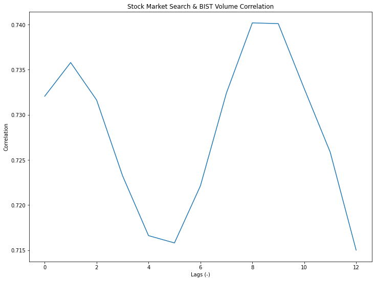

```python
best_lag_usd = get_best_lag(usd_df['USD/TL'], bist_vol_df['BIST Volume'], lags=13, x_label='Lags (-)', y_label='Correlation', title='Stock Market Search & BIST Volume Correlation')
```

```python
best_lag_usd
```

```
8
```

Lag 1 is used because it is more interpretable & its value is close to lag 8 correlation. This very high correlation of lag 1 is most likely due to the fact that stocks increase in price when the foreign currencies are not supressed (therefore increase).

### Linear Regression Models

```python
# Base BIST Volume X
bist_volume_X = sm.add_constant(stcmrkt_search_df['Stock Market SS'].iloc[3:])
bist_volume_X['Gold SS'] = gold_search_df['Gold SS'].shift(3).iloc[3:]
bist_volume_X['Interest Rate'] =  interest_rate_df['Interest Rate'].iloc[3:]
bist_volume_X['USD/TL'] = usd_df['USD/TL'].shift(1).iloc[3:]
bist_volume_X['trend'] = bist_volume_X.reset_index(drop=True).index
```

```python
bistvol_lr = sm.OLS(bist_vol_df['BIST Volume'].iloc[3:], bist_volume_X)
bistvol_lr = bistvol_lr.fit()
bistvol_lr.summary()
```

OLS Regression Results

| Dep. Variable: | BIST Volume | R-squared: | 0.850 |
| --- | --- | --- | --- |
| Model: | OLS | Adj. R-squared: | 0.842 |
| Method: | Least Squares | F-statistic: | 99.98 |
| Date: | Fri, 05 Apr 2024 | Prob (F-statistic): | 9.20e-35 |
| Time: | 15:26:19 | Log-Likelihood: | -1395.7 |
| No. Observations: | 94 | AIC: | 2803. |
| Df Residuals: | 88 | BIC: | 2819. |
| Df Model: | 5 |  |  |
| Covariance Type: | nonrobust |  |  |

|  | coef | std err | t | P>\|t\| | [0.025 | 0.975] |
| --- | --- | --- | --- | --- | --- | --- |
| const | -6.268e+04 | 2.83e+05 | -0.221 | 0.825 | -6.25e+05 | 5e+05 |
| Stock Market SS | 6.217e+04 | 5794.034 | 10.730 | 0.000 | 5.07e+04 | 7.37e+04 |
| Gold SS | 1.17e+04 | 7296.286 | 1.604 | 0.112 | -2799.080 | 2.62e+04 |
| Interest Rate | -5.185e+04 | 1.08e+04 | -4.800 | 0.000 | -7.33e+04 | -3.04e+04 |
| USD/TL | 1.802e+05 | 2.57e+04 | 7.000 | 0.000 | 1.29e+05 | 2.31e+05 |
| trend | -2.315e+04 | 7799.390 | -2.968 | 0.004 | -3.86e+04 | -7645.813 |

| Omnibus: | 22.682 | Durbin-Watson: | 1.279 |
| --- | --- | --- | --- |
| Prob(Omnibus): | 0.000 | Jarque-Bera (JB): | 65.257 |
| Skew: | 0.742 | Prob(JB): | 6.76e-15 |
| Kurtosis: | 6.802 | Cond. No. | 326. |

Notes:  
[1] Standard Errors assume that the covariance matrix of the errors is correctly specified.

```python
bist_res_arr = bistvol_lr.resid
```

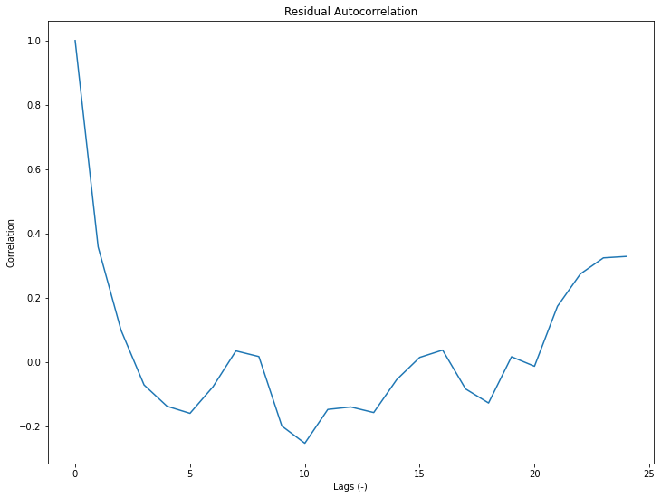

```
0
```

```python
get_best_lag(bist_res_arr, bist_res_arr, lags=25, x_label='Lags (-)', y_label='Correlation', title='Residual Autocorrelation')
```

Autocorrelation function of the residuals seems to be contained in a relatively large band, and there seems to be a seasonality. Therefore seasonal binary features will be added.

```python
# Some seasonality in base model residuals, so added seasonal binary features
bist_volume_X = bist_volume_X.join(pd.get_dummies(pd.to_datetime(stcmrkt_search_df['Date'].iloc[1:]).dt.month%12 // 3 + 1, drop_first=True).astype(int))
```

```python
bistvol_lr = sm.OLS(bist_vol_df['BIST Volume'].iloc[3:], bist_volume_X)
bistvol_lr = bistvol_lr.fit()
bistvol_lr.summary()
```

OLS Regression Results

| Dep. Variable: | BIST Volume | R-squared: | 0.863 |
| --- | --- | --- | --- |
| Model: | OLS | Adj. R-squared: | 0.850 |
| Method: | Least Squares | F-statistic: | 66.86 |
| Date: | Fri, 05 Apr 2024 | Prob (F-statistic): | 2.02e-33 |
| Time: | 15:26:19 | Log-Likelihood: | -1391.5 |
| No. Observations: | 94 | AIC: | 2801. |
| Df Residuals: | 85 | BIC: | 2824. |
| Df Model: | 8 |  |  |
| Covariance Type: | nonrobust |  |  |

|  | coef | std err | t | P>\|t\| | [0.025 | 0.975] |
| --- | --- | --- | --- | --- | --- | --- |
| const | 3.233e+05 | 3.09e+05 | 1.047 | 0.298 | -2.91e+05 | 9.37e+05 |
| Stock Market SS | 6.122e+04 | 5709.061 | 10.723 | 0.000 | 4.99e+04 | 7.26e+04 |
| Gold SS | 1.293e+04 | 7142.841 | 1.810 | 0.074 | -1270.353 | 2.71e+04 |
| Interest Rate | -5.469e+04 | 1.07e+04 | -5.110 | 0.000 | -7.6e+04 | -3.34e+04 |
| USD/TL | 1.797e+05 | 2.51e+04 | 7.167 | 0.000 | 1.3e+05 | 2.3e+05 |
| trend | -2.331e+04 | 7640.123 | -3.051 | 0.003 | -3.85e+04 | -8117.394 |
| 2 | -5.222e+05 | 2.04e+05 | -2.558 | 0.012 | -9.28e+05 | -1.16e+05 |
| 3 | -4.346e+05 | 2e+05 | -2.172 | 0.033 | -8.32e+05 | -3.68e+04 |
| 4 | -2.379e+05 | 2.02e+05 | -1.177 | 0.242 | -6.4e+05 | 1.64e+05 |

| Omnibus: | 13.757 | Durbin-Watson: | 1.400 |
| --- | --- | --- | --- |
| Prob(Omnibus): | 0.001 | Jarque-Bera (JB): | 30.461 |
| Skew: | 0.456 | Prob(JB): | 2.43e-07 |
| Kurtosis: | 5.636 | Cond. No. | 420. |

Notes:  
[1] Standard Errors assume that the covariance matrix of the errors is correctly specified.

```python
bist_res_arr = bistvol_lr.resid
```

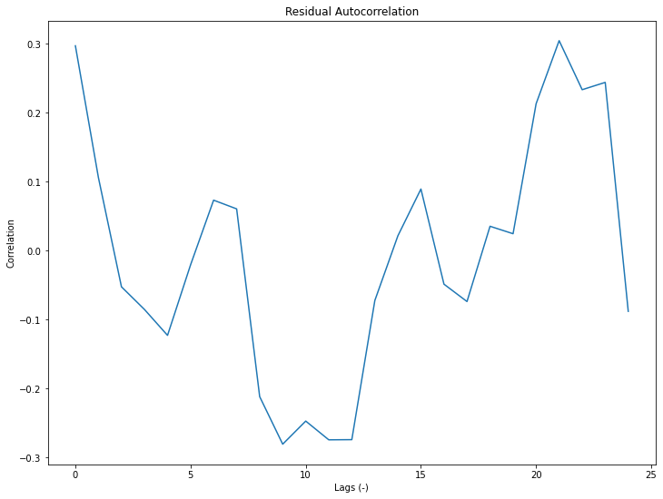

```
21
```

```python
get_best_lag(bist_res_arr.shift(1).iloc[1:], bist_res_arr.iloc[1:], lags=25, x_label='Lags (-)', y_label='Correlation', title='Residual Autocorrelation')
```

The residual autocorrelations are contained in a smaller band compared to the base model and are relatively small. The Adjusted R^2 value is high as well, therefore further residual analysis is needed to check modelling assumptions.

### Residual Analysis

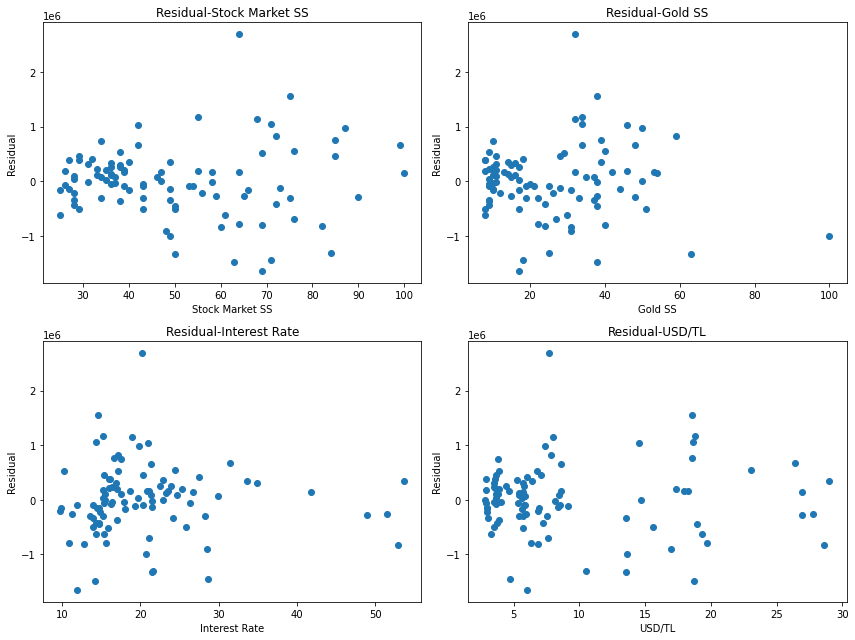

```python
# Residuals - Features
fig, ax_arr = plt.subplots(nrows=2, ncols=2, figsize=(12, 9))

a = 1
for i in range(2):
    for j in range(2):
        ax = ax_arr[i, j]
        comp_feature = bist_volume_X.columns[a]
        ax.scatter(bist_volume_X[comp_feature], bist_res_arr)
        ax.set_title('Residual-' + comp_feature)
        ax.set_xlabel(comp_feature)
        ax.set_ylabel('Residual')
        a+=1

plt.tight_layout()
plt.show()
```

There seems to be no obvious pattern between the features and the residuals.

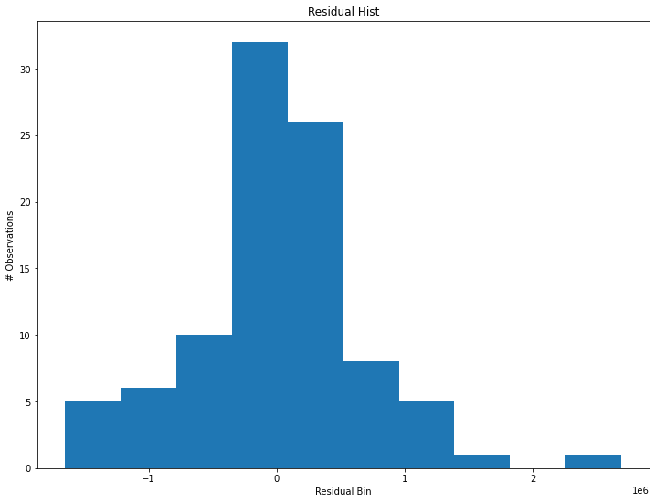

```python
# Residual histogram
plt.figure(figsize=(12, 9))
plt.title('Residual Hist')
plt.hist(bist_res_arr)
plt.xlabel('Residual Bin')
plt.ylabel('# Observations')
```

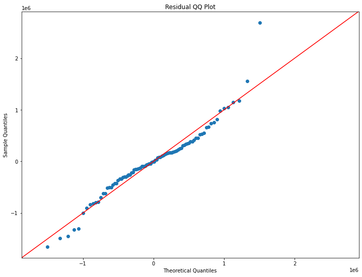

```python
plt.figure(figsize=(12, 9))
ax = plt.subplot()
sm.qqplot(bist_res_arr, loc=0, scale=bist_res_arr.std(), ax=ax, line='45')
plt.title('Residual QQ Plot')
plt.show()
```

Residuals seems to be distributed normally, however, there are some points that the model can't explain (so there are more information which can be included in the model to explain the target).

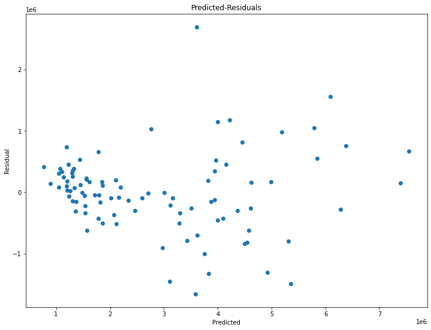

```python
# Residuals - Predicted
plt.figure(figsize=(12, 9))
plt.scatter(bistvol_lr.predict(bist_volume_X), bist_res_arr)
plt.title('Predicted-Residuals')
plt.xlabel('Predicted')
plt.ylabel('Residual')
```

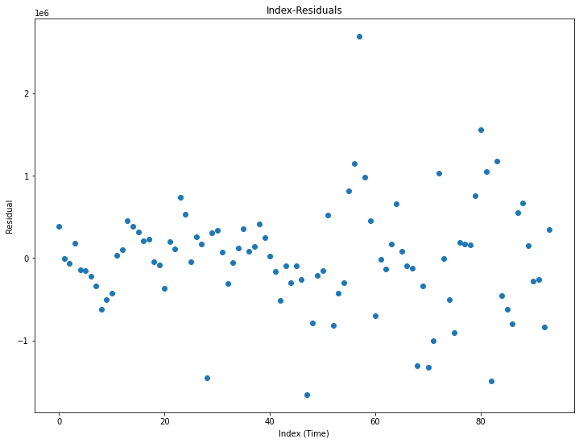

```python
plt.figure(figsize=(12, 9))
plt.scatter(range(len(bist_res_arr)), bist_res_arr)
plt.title('Index-Residuals')
plt.xlabel('Index (Time)')
plt.ylabel('Residual')
```

There is an increasing variance overtime which is discussed in EDA section and apparent in the plot of the target as well. Splitting the time space into two with a binary variable potentially can solve this, or dropping some of the data to analyze a single regime period since there seems to be regime change after 2019.

```python
sm.stats.acorr_ljungbox(bist_res_arr, lags=[12], return_df=True)
```

|  | lb_stat | lb_pvalue |
| --- | --- | --- |
| 12 | 37.233215 | 0.000205 |

```python
sm.stats.acorr_ljungbox(bist_res_arr, lags=[24], return_df=True)
```

|  | lb_stat | lb_pvalue |
| --- | --- | --- |
| 24 | 65.458514 | 0.00001 |

There are significant autocorrelation in the residuals which indicates that there are significant factors this model can't explain. This is very understandable, explaining the economical variables in current conditions is not very reliable, atleast with these data resources.

## Unemployment

Unemployment is an highly important economical and social parameter. With the current conditions, it is expected to be hard to predict. This is because even though it is not in monetary terms, it is influenced by economical conditions a lot.

Interested questions in this analysis:

- Does online Linkedin search affect the unemployment?
- Does online job search have an impact on the unemployment?
- Does USD exchange rate have an effect on the unemployment?
- Did Covid-19 have an effect on the unemployment?
- Is there a trend or seasonality in the the unemployment?